# PAC4 - Anàlisi de variànçia i repàs del curs

Albert Costas Gutierrez

18 de junio 2018

# 1 Preprocessat

## 1.1 Carrega de les dades

**Carregar el fitxer de dades “Fumadores.csv”.**

```r
# Carregar el fitxer de dades en R
mydata <- read.csv2(file = "Fumadores.csv", header = TRUE, sep = ",", quote = "\"", dec = ".", fill = TRUE, encoding="UTF-8")
n.var <- names(mydata)
# breu resumen dels atributs
head(mydata, n=5)
```

| AE | Tipo |
| --- | --- |
| 4.0100 | NF |
| 4.8772 | NF |
| 4.2927 | NF |
| 4.9475 | NF |
| 4.1266 | NF |

## 1.2 Tipus de dades

**Consultar els tipus de dades de les variables i si és necessari, aplicar les conversions adequades. Esbrinar possibles inconsistències en els valors de Tipus o AE. En el cas que existan inconsistències, corregir-les.**

```r
summary(mydata)
```

```
##        AE             Tipo
##  Min.   :1.038   FI     :20
##  1st Qu.:2.519   FM     :20
##  Median :2.954   FP     :20
##  Mean   :3.074   NF     :19
##  3rd Qu.:3.627   FL     :16
##  Max.   :5.284   NI     :16
##                  (Other): 8
```

```r
res <- sapply(mydata,class)

kable(data.frame(
    variables = names(res),
    clase = as.vector(res)
))
```

| variables | clase |
| --- | --- |
| AE | numeric |
| Tipo | factor |

```r
summary(mydata$Tipo)
```

```
## FI fL FL FM FP NF ni NI
## 20  3 16 20 20 19  5 16
```

```r
mydata <- as.data.frame(sapply(mydata, toupper))
summary(mydata$Tipo)
```

```
## FI FL FM FP NF NI
## 20 19 20 20 19 21
```

```r
mydata$AE <- as.numeric(as.character(mydata$AE))
summary(mydata)
```

```
##        AE        Tipo
##  Min.   :1.038   FI:20
##  1st Qu.:2.519   FL:19
##  Median :2.954   FM:20
##  Mean   :3.074   FP:20
##  3rd Qu.:3.627   NF:19
##  Max.   :5.284   NI:21
```

## 1.3 Realitzar un anàlisi descriptiu de la mostra en la seva totalitat en relació a la variable AE

```r
mean(mydata$AE)
```

```
## [1] 3.07446
```

```r
sd(mydata$AE)
```

```
## [1] 0.8704699
```

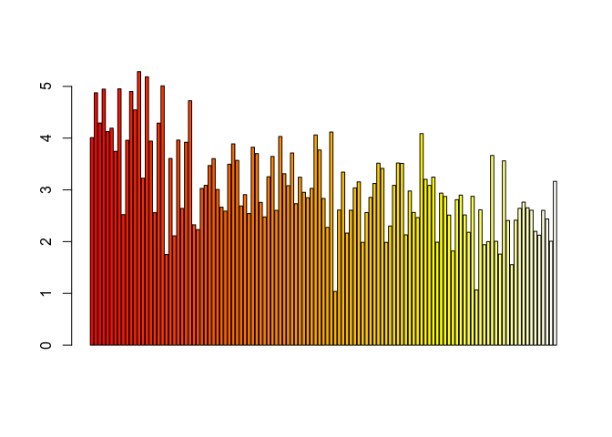

```r
barplot(mydata$AE, col=heat.colors(length(unique(mydata$AE))))
```

## 1.4 Analitzar les dades segons el tipus de fumador

**Mostrar el número de persones en cada tipus, la mitjana d’AE cada grup i un boxplot on es mostra la distribució d’AE per cada tipus, etc. Es recomana ordenar els gràfics de menys a més AE. Per calcular la mitjana o altres variables per cada tipus de fumador, podeu usar les funcions summarize y group_by de la llibreria dplyr que us seràn de gran utilitat. Per realitzar la visualització de les dades, podeu usar la funció ggplot de la llibreria ggplot2.**

```r
by_Tipo <- mydata %>%
  group_by(Tipo) %>%
  summarise(mean = mean(AE), sd = sd(AE))

by_Tipo
```

| Tipo | mean | sd |
| --- | --- | --- |
| FI | 2.456500 | 0.5515356 |
| FL | 2.773679 | 0.7182298 |
| FM | 2.687775 | 0.6575152 |
| FP | 3.118690 | 0.7497423 |
| NF | 4.240605 | 0.8100596 |
| NI | 3.206190 | 0.5025607 |

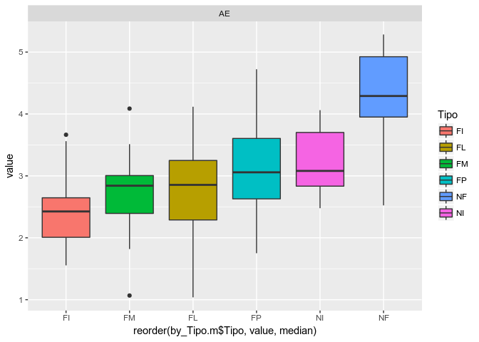

```r
by_Tipo.m <- melt(mydata, id.var = "Tipo")

p <- ggplot(data = by_Tipo.m, aes(x = reorder(by_Tipo.m$Tipo, value, median), y=value)) + geom_boxplot(aes(fill=Tipo))
p + facet_wrap( ~ variable, scales="free")
```

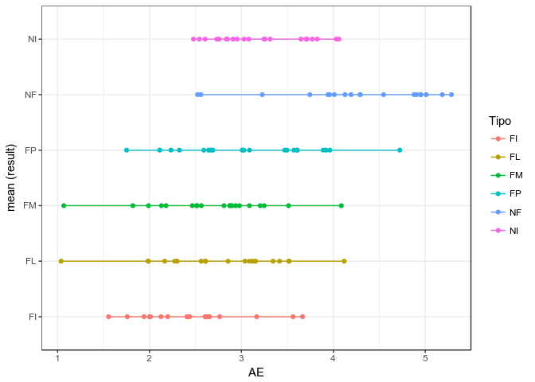

```r
ggplot(data = mydata, aes(x = AE, y = Tipo, colour = Tipo, group = Tipo)) +
    stat_summary(fun.y = mean, geom = "point") + stat_summary(fun.y = mean,
    geom = "line") + labs(y = "mean (result)") + theme_bw()
```

# 2 Interval de confiança

**Calcular l’interval de confiança de la capacitat pulmonar de tota la mostra. El nivell de confiança és 95%. Realitzar el càlcul manualment sense usar les funcions t.test o equivalents. Podeu usar qnorm, qt, pnorm, pt, . . . En quant a l’elecció del mètode pel càlcul de l’interval de confiança, s’ha de justificar la vostra elecció.**

$\overline{x} \pm Z_{\propto / 2} * \frac{\delta}{\sqrt{n}}$

Seleciona la mitjana i la $\pm$ per obtenir el marge d’error, utlitzem les funciones anteriors per calcular la mitjana, el valor critic i l’estadictic de contrast:

```r
mitajana_function <- function(dataList) {
  iterator <- 0
  sum <- 0
  for (item in dataList) {
    sum <- sum + item
    iterator <- iterator + 1
  }

  return (sum / iterator)
}

## funció per calcular la desviació tipica
desviacion_tipica_function <- function(dataset, mitjana_mostral, n)
{
  #calculem la variància i posteriorment la desviació típica
  vtemp = 0
  for(v in dataset) {
    vtemp = vtemp + ((v - mitjana_mostral)^2)
  }
  variancia = vtemp/n

  #calculem la desviació típica
  return  = sqrt(variancia)
}

#funcio per calcular el valor critic
valor_critic_funtion <- function(percentatge, graus) {
  return (qt(percentatge, graus))
}

## funció per calcular l'interval de confiança
intertal_confiança_funtion <- function(dataset, percentage_conf, mitjana_poblacional) {

    #obtenim el nombre de mostres
    n <- length(dataset)

   mitjana_mostral = mitajana_function(dataset)

    valCritic <- valor_critic_funtion(
         percentage_conf/100,
        (n - 1)
    )


    #primer calculem la variància i posteriorment la desviació típica
  o = desviacion_tipica_function(dataset, mitjana_mostral, n)

  errorStd <- (o/ (sqrt(length(dataset)) - 1))

    return (
    list(
       (mitjana_mostral - (valCritic * errorStd)),
       (mitjana_mostral + (valCritic * errorStd))
     )
    )
}


list[interval_de_conf_inf, interval_de_conf_sup] <- intertal_confiança_funtion(
    mydata$AE,
    95,
    5
)

c(interval_de_conf_inf, interval_de_conf_sup)
```

```
## [1] 2.929431 3.219489
```

# 3 Comparació de dues mostres: Fumadors vs No Fumadors

**Podem afirmar que la capacitat pulmonar del fumadors és inferior a la de no fumadors? Inclou dintre de la categoria de no fumadors els fumadors pasius. Realitzar el càlcul manualment sense usar les funcions t.test o equivalents. Podeu usar qnorm, qt, pnorm, pt, . . . Seguir els passos que s’indican a continuació.**

## 3.1 Escriure la hipótesi nul·la i alternativa

#### 3.1.0.1 Hipòtesi nul·la

$H_0: \mu_1 - \mu_2 = 0$

#### 3.1.0.2 Hipòtesi alternativa

$H_1: \mu_1 - \mu_2 < 0$

Assignem a $\mu_1$ a la capacitat pulmonar dels no fumadors és igual a la dels fumadors a $\mu_2$ a la capacitat dels no fumadors és superior a la dels fumadors.

## 3.2 Preparar les dades per realitzar el contrast

```r
noFumadors <- mydata[(mydata$Tipo == "NF") | (mydata$Tipo == "FP"),]
head(noFumadors, n=5)
```

| AE | Tipo |
| --- | --- |
| 4.0100 | NF |
| 4.8772 | NF |
| 4.2927 | NF |
| 4.9475 | NF |
| 4.1266 | NF |

```r
length(noFumadors$AE)
```

```
## [1] 39
```

```r
fumadors <- mydata[!(mydata$Tipo == "NF") & !(mydata$Tipo == "FP"),]
head(fumadors, n=5)
```

|  | AE | Tipo |
| --- | --- | --- |
| 40 | 2.9084 | NI |
| 41 | 2.5423 | NI |
| 42 | 3.8249 | NI |
| 43 | 3.7012 | NI |
| 44 | 2.7578 | NI |

```r
length(fumadors$AE)
```

```
## [1] 80
```

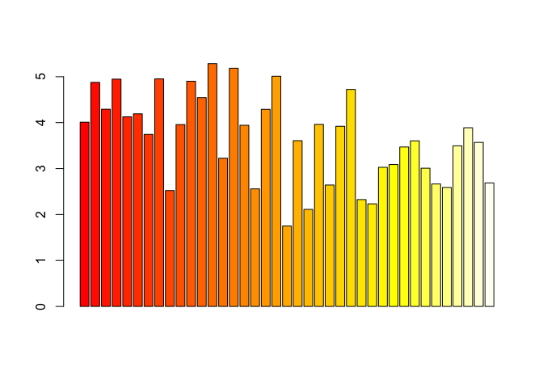

```r
barplot(noFumadors$AE, col=heat.colors(length(unique(noFumadors$AE))))
```

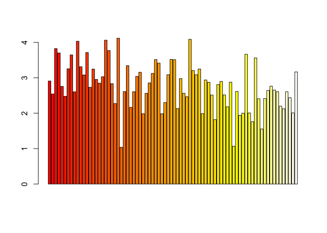

```r
barplot(fumadors$AE, col=heat.colors(length(unique(fumadors$AE))))
```

## 3.3 Especificar quin tipus de contrast aplicareu

Es tracta de mosters independets perque son persones diferentes les que estan al grup de fumadors y els de no fumadors, sera contrat de hipótesis en mostres indepents. D’altra banda les dos mostres son del mateix camp, però estan disciminades pel camp de tipus,… llavors la variància, tot i ser deconeguda, es la igual, en aquest sentit aplicarem constras sobre la diferència de mitjanes per variàncies poblacionals desconegues però iguals.

## 3.4 Realitzar els càlculs del valor p

$T=\frac{\begin{pmatrix}\textstyle\overline{X_1}-\overline X_2\end{pmatrix}-\left(\mu_1-\mu_2\right)}{SE}\;=\;t\left(df\right)$

$SE=\sqrt{\frac{\displaystyle\widehat{S_1^2}}{n_1}+\frac{\widehat{S_2^2}}{n_2}}$

El nivell de significació o alta es $\alpha$ = 0.05, ja que el nivell de confiança és 95%

```r
variancia_function <- function(dataList) {
  dataMean <- mean(dataList)
  totalItems <- length(dataList)
  suma <- 0
  for(item in dataList) {
    suma <- suma + ((item - dataMean)^2)
  }

  return (suma / (totalItems - 1))
}

calcul_estadictic_mitjana <- function(dataList1, dataList2, mu1, mu2) {
  totalMostres1 <- length(dataList1)
  totalMostres2 <- length(dataList2)

  mean1 <- mitajana_function(dataList1)
  mean2 <- mitajana_function(dataList2)

    return (
    (mean1 - mean2) / (SE_function(dataList1, dataList2, mean1, mean2))
  )
}

SE_function <- function(dataList1, dataList2,mean1,mean2) {

  totalMostres1 <- length(dataList1)
  totalMostres2 <- length(dataList2)

  sd1 <- variancia_function(dataList1)
  sd2 <- variancia_function(dataList2)

  return (sqrt((sd1^2 / totalMostres1) + (sd2^2 / totalMostres2)))
}

tValue2mean <- calcul_estadictic_mitjana(
  fumadors$AE,
  noFumadors$AE,
  mitajana_function(fumadors$AE),
  mitajana_function(noFumadors$AE)
)

tValue2mean
```

```
## [1] -5.694068
```

### 3.4.1 El valor critic: n+m-2

```r
grados_de_libertat = ((length(fumadors$AE)+length(noFumadors$AE))-2)
v_critic_2 = valor_critic_funtion(
  0.95,
  grados_de_libertat
  )

v_critic_2
```

```
## [1] 1.657982
```

$pvalue\;=\;P(\vert T_{\;calculada}\vert\;>=t_{df},_{1-\alpha/2})$

```r
p_valor_2_function <- function(tValue, itemsList1, itemsList2) {
  df1 = length(itemsList1) - 1
  df2 = length(itemsList2) - 1
  return (pt(-abs(tValue), df1) + (1 - pt(abs(tValue), df2)))
}

p_value_2 = p_valor_2_function(
  tValue2mean,
  fumadors$AE,
  noFumadors$AE
)
p_value_2
```

```
## [1] 8.499471e-07
```

El valor p és 8.499470910^{-7}

## 3.5 Interpretar el resultat del contrast

Rebutjar Hipòstasi nul·la $H_o\;$ perque el p-value $\leq \alpha$ en aquest cas $\alpha$ = 0.05. Donat aquest resultat descartem la hipòtesi nul·la i per tant podem dir a la capacitat dels no fumadors és superior a la dels fumadors.

El p-valor ens proporciona el grau de credibilitat de la hipòtesi nul·la: com el valor de p és “molt petit” (inferior a 0,005), significa que la hipòtesi nul·la és del tot increïble (sobre la base de les observacions obtingudes), i per tant la descartem.

# 4 ANOVA

**A continuació es realitzarà una anàlisi de variància, on es vol comparar la capacitat pulmonar entre els sis tipus de fumadors no fumadors classificats prèviament. L’anàlisi de variància consisteix a avaluar si la variabilitat d’una variable dependent pot explicar-se a partir d’una o diverses variables independents, denominades factors. En el cas que ens ocupa, ens interessa avaluar si la variabilitat de la variable AE pot explicar-se pel factor tipus de fumador. Hi ha dues preguntes bàsiques a respondre:**

• Hi ha diferències entre la capacitat pulmonar (AE) entre els diferents tipus de fumadors/no fumadors?

• Si hi ha diferències, entre quins grups estan aquestes diferències?

**Per a la resolució d’aquesta secció, se seguiran els apunts de López-Roldán i Fachelli (2015).**

## 4.1 Verificar l’assumpció de normalitat

**Atenent al material, gràfic III.8.6 i pàgina 25, avaluar si el conjunt de dades compleix les condicions d’aplicació d’ANOVA. Seguiu els passos que s’indiquen a continuació.**

### 4.1.1 Representar gràficament la normalitat de la mostra de dades AE amb la funció qqnorm

Dibuixem la línia de la normal

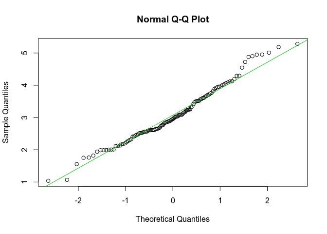

```r
qqnorm(mydata$AE)
qqline(mydata$AE, col = 3)
```

### 4.1.2 Escriure la hipòtesi nul·la i la hipòtesi alternativa

$H_0:$ La distribució de dades segueix la normal

$H_1:$ La distribució de dades no segueix la normal

### 4.1.3 Aplicar un test de normalitat

**Aplicar un test de normalitat, seguint les recomanacions del material esmentat López-Roldán i Fachelli (2015). Justificar l’elecció.**

```r
test.shapiro <- shapiro.test(mydata$AE)
test.shapiro
```

```
##
##  Shapiro-Wilk normality test
##
## data:  mydata$AE
## W = 0.97845, p-value = 0.05293
```

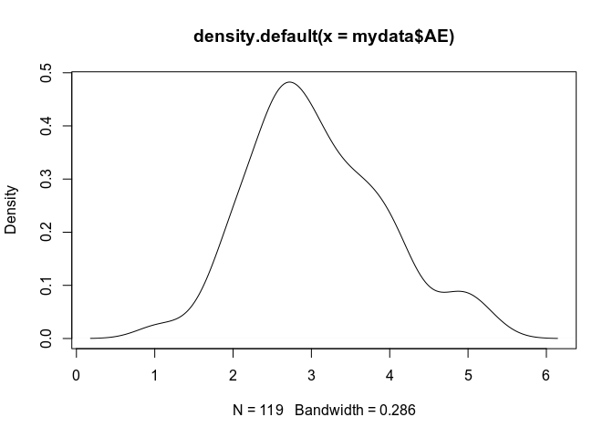

```r
plot(density(mydata$AE))
```

### Interpretar els resultats a partir del gràfic qqnorm i dels valors que retorna el test.

En aquest cas el valor p-value (0.0529277) és més gran que 0.05 per tant podem acceptar la hipòtesi nul·la, afirmen que es tracta una distribució de dades normal.

## 4.2 Homoscedasticitat: Homogeneïtat de variàncies

**Una altra de les condicions d’aplicació d’ANOVA és la igualtat de variàncies (homoscedasticitat). Aplicar un test per validar si els grups presenten igual variància. Seguiu les indicacions dels apunts de López-Roldán i Fachelli (2015).**

### 4.2.1 Escriure la hipòtesi nul·la i la hipòtesi alternativa

#### 4.2.1.1 hipotesi nul·la

$H_0: \sigma_0 = \sigma_1$

#### 4.2.1.2 hipotesi alternativa

$H_1: \sigma_0 \neq \sigma_1$

### 4.2.2 Realitzar els càlculs

```r
test.bart <- bartlett.test(mydata$AE~mydata$Tipo)
test.bart
```

```
##
##  Bartlett test of homogeneity of variances
##
## data:  mydata$AE by mydata$Tipo
## Bartlett's K-squared = 6.0904, df = 5, p-value = 0.2975
```

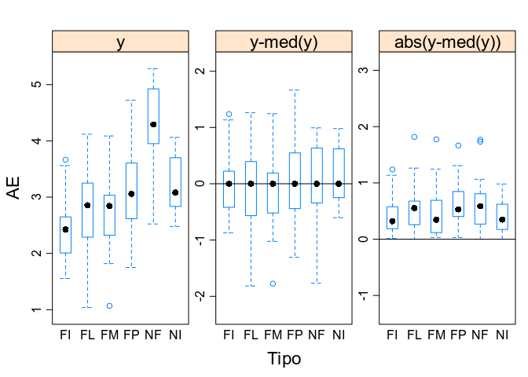

```r
hovPlot(AE~Tipo, data=mydata)
```

Podem veure que el valor p-value (0.2975217) és major que 0.05, per tant acceptem la hipòtesis nul·la, acceptem que no existeixen diferències entre les variàncies dels dos atributs.

Per altra banda, podem veure la desviació estàndard dels grups envers la capacitat pulmonar, podem veure que no es massa diferent.

```r
tapply(mydata$AE, mydata$Tipo, sd)
```

```
##        FI        FL        FM        FP        NF        NI
## 0.5515356 0.7182298 0.6575152 0.7497423 0.8100596 0.5025607
```

## 4.3 ANOVA unifactorial (One Way ANOVA)

**Calcular ANOVA d’un factor (one-way ANOVA o independent samples ANOVA) per investigar si hi ha diferències en el nivell d’aire expulsat (AE) entre els diferents tipus de fumadors.**

### 4.3.1 Escriure la hipòtesi nul·la i la hipòtesi alternativa

##### 4.3.1.0.1 Hipotesis nul·la

$H_0:\mu_0 = \mu_1$

##### 4.3.1.0.2 Hipotesis alternativa

$H_1:\mu_0 \neq \mu_1$

### 4.3.2 Realitzar els càlculs

**Podeu utilitzar la funció aov.**

```r
anova_4 <- aov(AE~Tipo, data=mydata)
summary(anova_4)
```

```
##              Df Sum Sq Mean Sq F value   Pr(>F)
## Tipo          5  38.59   7.718   17.16 1.33e-12 ***
## Residuals   113  50.82   0.450
## ---
## Signif. codes:  0 '***' 0.001 '**' 0.01 '*' 0.05 '.' 0.1 ' ' 1
```

### 4.3.3 Interpretar els resultats de la prova ANOVA i relacionar-los amb el resultat gràfic del boxplot

Podem veure que el valor p-value 1.332456610^{-12} és menor que 0,05, rebutgem la hipòtesi nul·la, afirmem que les mitjanes són diferents, per tant com a conclució la variable AE és pot explicar a partir de la variable independent de tipus de fumador.

Per altra banda observem que la mitjana dels grups envers la AE (capacitat pulmonar) són molt diferents entre elles.

```r
tapply(mydata$AE, mydata$Tipo, mean)
```

```
##       FI       FL       FM       FP       NF       NI
## 2.456500 2.773679 2.687775 3.118690 4.240605 3.206190
```